# Vehicle Loan Default Prediction

### Submitted by :

**Group 45**  
Akshay Prasannan - S3818611  
Amal Gopidasan Nair - S3820786  
Joel Varghese Cherian - S3808033

## Table of Content

1. Introduction
2. Objective  
   2.1. Phase 1 Objective  
   2.2. Phase 2 Objective
3. Dataset  
   3.1 Descriptive Features  
   3.2 Target Feature
4. Data Preparation and Exploratory Analysis  
   4.1 Preliminaries  
   4.2 Missing Values in the Dataset  
   4.3 Type of Attributes in the Dataset
5. Data Cleaning and Transformation  
   5.1 Data cleaning  
   5.1.1 Fixing column name  
   5.1.2 Fixing Missing Values  
   5.1.3 Fixing Type of attributes  
   5.2 Data Transformation  
   5.3 Dropping Attributes  
   5.4 Unique Values of Attributes
6. Summary Statistics
7. Data Visualization and Exploration  
   7.1 Univariate Visualization  
   7.2 Multivariate Visualization
8. Summary and Conclusion
9. Reference

# Introduction

In this present world where most people run the show with the help of various credits/loans provided by banks and other financial institutions. One major sector where a lot of credits or loans are involved is the automobile sector. Nowadays the vehicle loan defaults are on the higher side causing substantial loss to the financial institutions. As a result of which the loan underwriting has become more stringent and rejections due to the bad profile of the customer have increased due to this. The demand for an effective and efficient credit risk scoring model has increased among financial organizations.

# Objective

The objective of this project is to accurately model and predict the risk of a borrower defaulting on a vehicle loan in the first EMI( Equated monthly installment) on the due date. The project is divided into 2 phases. And in this report is on the **Phase 1** Objective.

### Phase 1 Objective

The main objective of Phase 1 is data pre-processing, data exploration and visualization.

### Phase 2 Objective

Phase 2 is on predictive modeling of data.

# Dataset

The original dataset is from L&T Financial Services & Analytics Vidhya presents ‘DataScience FinHack’ competition and we have taken it from https://www.kaggle.com/lampubhutia/loandefault-ltfs-avml-finhack . There were 2 datasets in the website, 'train.csv', and 'test.csv'. Train.csv is downloaded and renamed as loandefault.csv. We are considering only the train.csv in this project phase as the dataset and for data splitting, we would split the loandefault.csv in phase 2 as required. The dataset consists of 41 attributes in total, of which 40 are descriptive features and one target feature.

## Descriptive Features

|  | Variable | Description | Data_Type | Unit |  |
| --- | --- | --- | --- | --- | --- |
|  | UniqueID | Unique ID for identifying Customers. | Nominal category | Not Applicable |  |
|  | disbursed_amount | Loan Amount disbursed | Numerical | Indian Currency Rupees |  |
|  | asset_cost | The cost of asset | Numerical | Indian Currency Rupees |  |
|  | ltv | Loan to Value of the asset | Numerical | Percentage |  |
|  | branch_id | The branch where the loan was disbursed | Nominal category | Not Applicable |  |
|  | supplier_id | Vehicle dealer ID where loan was disbursed | Nominal category | Not Applicable |  |
|  | manufacturer_id | Vehicle manufacturer(Hero, Honda, TVS etc.) | Nominal category | Not Applicable |  |
|  | Current_pincode | Current pincode of the customer | Nominal category | Not Applicable |  |
|  | Date.of.Birth | Date of birth of the customer | Numerical | DD/MM/YYY |  |
|  | Employment.Type | Employment Type of the customer (Salaried/Self... | Nominal category | Not Applicable |  |
|  | DisbursalDate | Date of disbursement | Numerical | DD/MM/YYY |  |
|  | State_ID | State of disbursement | Nominal category | Not Applicable |  |
|  | Employee_code_ID | Employee of the organization who logged the di... | Nominal category | Not Applicable |  |
|  | MobileNo_Avl_Flag | Flagged as 1 if the mobile number is shared by... | Nominal category - Binary | Not Applicable |  |
|  | Aadhar_flag | Flagged as 1 if the mobile number is shared by... | Nominal category - Binary | Not Applicable |  |
|  | PAN_flag | Flagged as 1 if the PAN number is shared by th... | Nominal category - Binary | Not Applicable |  |
|  | VoterID_flag | Flagged as 1 if the Voter ID is shared by the ... | Nominal category - Binary | Not Applicable |  |
|  | Driving_flag | Flagged as 1 if the Driving license is shared ... | Nominal category - Binary | Not Applicable |  |
|  | Passport_flag | Flagged as 1 if the Passport is shared by the ... | Nominal category - Binary | Not Applicable |  |
|  | PERFORM_CNS.SCORE | Bureau Score | Numerical | Not Applicable |  |
|  | PERFORM_CNS.SCORE.DESCRIPTION | Bureau score description | Ordinal Category | Not Applicable |  |
|  | PRI.NO.OF.ACCTS | Total number of loan taken by the customer at ... | Numerical | Not Applicable |  |
|  | PRI.ACTIVE.ACCTS | Total number of active loan at time of disburs... | Numerical | Not Applicable |  |
|  | PRI.OVERDUE.ACCTS | Total number of default accounts at the time o... | Numerical | Not Applicable |  |
|  | PRI.CURRENT.BALANCE | Total principal outstanding amount of the acti... | Numerical | Indian Currency Rupees |  |
|  | PRI.SANCTIONED.AMOUNT | Total amount that was sanctioned for all the l... | Numerical | Indian Currency Rupees |  |
|  | PRI.DISBURSED.AMOUNT | Total amount that was disbursed for all the lo... | Numerical | Indian Currency Rupees |  |
|  | SEC.NO.OF.ACCTS | Total number of loan taken by the customer at ... | Numerical | Not Applicable |  |
|  | SEC.ACTIVE.ACCTS | Total number of active loan at time of disburs... | Numerical | Not Applicable |  |
|  | SEC.OVERDUE.ACCTS | Total number of default accounts at the time o... | Numerical | Not Applicable |  |
|  | SEC.CURRENT.BALANCE | Total principal outstanding amount of the acti... | Numerical | Indian Currency Rupees |  |
|  | SEC.SANCTIONED.AMOUNT | Total amount that was sanctioned for all the l... | Numerical | Indian Currency Rupees |  |
|  | SEC.DISBURSED.AMOUNT | Total amount that was disbursed for all the lo... | Numerical | Indian Currency Rupees |  |
|  | PRIMARY.INSTAL.AMT | EMI Amount of the primary loan | Numerical | Indian Currency Rupees |  |
|  | SEC.INSTAL.AMT | EMI Amount of the secondary loan | Numerical | Indian Currency Rupees |  |
|  | NEW.ACCTS.IN.LAST.SIX.MONTHS | New loans taken by the customer in last 6 mont... | Numerical | Not Applicable |  |
|  | DELINQUENT.ACCTS.IN.LAST.SIX.MONTHS | Loans defaulted in the last 6 months | Numerical | Not Applicable |  |
|  | AVERAGE.ACCT.AGE | Average loan tenure | Numerical | MM/YY |  |
|  | CREDIT.HISTORY.LENGTH | Time since first loan | Numerical | MM/YY |  |
|  | NO.OF_INQUIRIES | Enquries done by the customer for loans | Numerical | Not Applicable |  |
|  | loan_default | whether payment default on the first EMI. 0:no... | Nominal category - Binary | Not Applicable |  |

## Target Feature

The target feature is :  
**loan_default** : It is payment default on the first EMI. The target feature has two levels, `0` and `1`.

- `0` denoting no default in the first EMI payment
- `1` denoting default in the first EMI payment

# Data Preparation and Exploratory Analysis

## Preliminaries

```python
#Importing Modules
import pandas as pd
import numpy as np
import matplotlib.pyplot as mpt
import seaborn as sb
import warnings
warnings.filterwarnings("ignore")
```

First we load the dataset and print all the heads of columns for initial inspection

```python
ldd=pd.read_csv('Data_Group45.csv',sep=',')
pd.set_option('display.max_columns', None)
ldd.head()
```

|  | UniqueID | disbursed_amount | asset_cost | ltv | branch_id | supplier_id | manufacturer_id | Current_pincode_ID | Date.of.Birth | Employment.Type | DisbursalDate | State_ID | Employee_code_ID | MobileNo_Avl_Flag | Aadhar_flag | PAN_flag | VoterID_flag | Driving_flag | Passport_flag | PERFORM_CNS.SCORE | PERFORM_CNS.SCORE.DESCRIPTION | PRI.NO.OF.ACCTS | PRI.ACTIVE.ACCTS | PRI.OVERDUE.ACCTS | PRI.CURRENT.BALANCE | PRI.SANCTIONED.AMOUNT | PRI.DISBURSED.AMOUNT | SEC.NO.OF.ACCTS | SEC.ACTIVE.ACCTS | … |
| --- | --- | --- | --- | --- | --- | --- | --- | --- | --- | --- | --- | --- | --- | --- | --- | --- | --- | --- | --- | --- | --- | --- | --- | --- | --- | --- | --- | --- | --- | --- |
| 0 | 420825 | 50578 | 58400 | 89.55 | 67 | 22807 | 45 | 1441 | 01/01/1984 | Salaried | 03/08/2018 | 6 | 1998 | 1 | 1 | 0 | 0 | 0 | 0 | 0 | No Bureau History Available | 0 | 0 | 0 | 0 | 0 | 0 | 0 | 0 | … |
| 1 | 537409 | 47145 | 65550 | 73.23 | 67 | 22807 | 45 | 1502 | 31/07/1985 | Self employed | 26/09/2018 | 6 | 1998 | 1 | 1 | 0 | 0 | 0 | 0 | 598 | I-Medium Risk | 1 | 1 | 1 | 27600 | 50200 | 50200 | 0 | 0 | … |
| 2 | 417566 | 53278 | 61360 | 89.63 | 67 | 22807 | 45 | 1497 | 24/08/1985 | Self employed | 01/08/2018 | 6 | 1998 | 1 | 1 | 0 | 0 | 0 | 0 | 0 | No Bureau History Available | 0 | 0 | 0 | 0 | 0 | 0 | 0 | 0 | … |
| 3 | 624493 | 57513 | 66113 | 88.48 | 67 | 22807 | 45 | 1501 | 30/12/1993 | Self employed | 26/10/2018 | 6 | 1998 | 1 | 1 | 0 | 0 | 0 | 0 | 305 | L-Very High Risk | 3 | 0 | 0 | 0 | 0 | 0 | 0 | 0 | … |
| 4 | 539055 | 52378 | 60300 | 88.39 | 67 | 22807 | 45 | 1495 | 09/12/1977 | Self employed | 26/09/2018 | 6 | 1998 | 1 | 1 | 0 | 0 | 0 | 0 | 0 | No Bureau History Available | 0 | 0 | 0 | 0 | 0 | 0 | 0 | 0 | … |

Now, lets see the dimension of the datasets and list out all the columns names to check if it matches the original dataset

```python
list(ldd.columns)
```

```
['UniqueID',
 'disbursed_amount',
 'asset_cost',
 'ltv',
 'branch_id',
 'supplier_id',
 'manufacturer_id',
 'Current_pincode_ID',
 'Date.of.Birth',
 'Employment.Type',
 'DisbursalDate',
 'State_ID',
 'Employee_code_ID',
 'MobileNo_Avl_Flag',
 'Aadhar_flag',
 'PAN_flag',
 'VoterID_flag',
 'Driving_flag',
 'Passport_flag',
 'PERFORM_CNS.SCORE',
 'PERFORM_CNS.SCORE.DESCRIPTION',
 'PRI.NO.OF.ACCTS',
 'PRI.ACTIVE.ACCTS',
 'PRI.OVERDUE.ACCTS',
 'PRI.CURRENT.BALANCE',
 'PRI.SANCTIONED.AMOUNT',
 'PRI.DISBURSED.AMOUNT',
 'SEC.NO.OF.ACCTS',
 'SEC.ACTIVE.ACCTS',
 'SEC.OVERDUE.ACCTS',
 'SEC.CURRENT.BALANCE',
 'SEC.SANCTIONED.AMOUNT',
 'SEC.DISBURSED.AMOUNT',
 'PRIMARY.INSTAL.AMT',
 'SEC.INSTAL.AMT',
 'NEW.ACCTS.IN.LAST.SIX.MONTHS',
 'DELINQUENT.ACCTS.IN.LAST.SIX.MONTHS',
 'AVERAGE.ACCT.AGE',
 'CREDIT.HISTORY.LENGTH',
 'NO.OF_INQUIRIES',
 'loan_default']
```

## Missing Values in the Dataset

```python
print('Missing values')
ldd.isnull().sum()
```

```
Missing values
```

```
UniqueID                                  0
disbursed_amount                          0
asset_cost                                0
ltv                                       0
branch_id                                 0
supplier_id                               0
manufacturer_id                           0
Current_pincode_ID                        0
Date.of.Birth                             0
Employment.Type                        7661
DisbursalDate                             0
State_ID                                  0
Employee_code_ID                          0
MobileNo_Avl_Flag                         0
Aadhar_flag                               0
PAN_flag                                  0
VoterID_flag                              0
Driving_flag                              0
Passport_flag                             0
PERFORM_CNS.SCORE                         0
PERFORM_CNS.SCORE.DESCRIPTION             0
PRI.NO.OF.ACCTS                           0
PRI.ACTIVE.ACCTS                          0
PRI.OVERDUE.ACCTS                         0
PRI.CURRENT.BALANCE                       0
PRI.SANCTIONED.AMOUNT                     0
PRI.DISBURSED.AMOUNT                      0
SEC.NO.OF.ACCTS                           0
SEC.ACTIVE.ACCTS                          0
SEC.OVERDUE.ACCTS                         0
SEC.CURRENT.BALANCE                       0
SEC.SANCTIONED.AMOUNT                     0
SEC.DISBURSED.AMOUNT                      0
PRIMARY.INSTAL.AMT                        0
SEC.INSTAL.AMT                            0
NEW.ACCTS.IN.LAST.SIX.MONTHS              0
DELINQUENT.ACCTS.IN.LAST.SIX.MONTHS       0
AVERAGE.ACCT.AGE                          0
CREDIT.HISTORY.LENGTH                     0
NO.OF_INQUIRIES                           0
loan_default                              0
dtype: int64
```

## Type of Attributes in the Dataset

```python
print(f"Data type of Attributes:")
print(ldd.dtypes)
```

```
Data type of Attributes:
UniqueID                                 int64
disbursed_amount                         int64
asset_cost                               int64
ltv                                    float64
branch_id                                int64
supplier_id                              int64
manufacturer_id                          int64
Current_pincode_ID                       int64
Date.of.Birth                           object
Employment.Type                         object
DisbursalDate                           object
State_ID                                 int64
Employee_code_ID                         int64
MobileNo_Avl_Flag                        int64
Aadhar_flag                              int64
PAN_flag                                 int64
VoterID_flag                             int64
Driving_flag                             int64
Passport_flag                            int64
PERFORM_CNS.SCORE                        int64
PERFORM_CNS.SCORE.DESCRIPTION           object
PRI.NO.OF.ACCTS                          int64
PRI.ACTIVE.ACCTS                         int64
PRI.OVERDUE.ACCTS                        int64
PRI.CURRENT.BALANCE                      int64
PRI.SANCTIONED.AMOUNT                    int64
PRI.DISBURSED.AMOUNT                     int64
SEC.NO.OF.ACCTS                          int64
SEC.ACTIVE.ACCTS                         int64
SEC.OVERDUE.ACCTS                        int64
SEC.CURRENT.BALANCE                      int64
SEC.SANCTIONED.AMOUNT                    int64
SEC.DISBURSED.AMOUNT                     int64
PRIMARY.INSTAL.AMT                       int64
SEC.INSTAL.AMT                           int64
NEW.ACCTS.IN.LAST.SIX.MONTHS             int64
DELINQUENT.ACCTS.IN.LAST.SIX.MONTHS      int64
AVERAGE.ACCT.AGE                        object
CREDIT.HISTORY.LENGTH                   object
NO.OF_INQUIRIES                          int64
loan_default                             int64
dtype: object
```

# Data Cleaning and Transformation

## Data cleaning

Upon initial inspection of the dataset we found the following issues with the data:

- Some of the columns are not named properly
- The attribute `Employment.Type` consist of 7661 missing value
- The type of attributes are not defined properly (for eg date, categorical values etc)

### Fixing column name

Changing column names for better visualization and modeling:

The following are the description of changed column name:

- "ltv" to "Loan to Value of the asset
- "PERFORM_CNS.SCORE" to "Bureau Score"
- "PERFORM_CNS.SCORE.DESCRIPTION" to "Bureau score description"
- "PRIMARY.INSTAL.AMT" to "Primary_EMI"
- "SEC.INSTAL.AMT "to" Secondary_EMI"
- "DELINQUENT.ACCTS.IN.LAST.SIX.MONTHS" to "Default_Acct_in_6_months"
- "AVERAGE.ACCT.AGE" to "Average_Tenure"
- "Date.of.Birth" to "DOB"

```python
ldd=ldd.rename(columns={"ltv":"Loan to Value of the asset",
"PERFORM_CNS.SCORE":"Bureau Score",
"PERFORM_CNS.SCORE.DESCRIPTION":"Bureau score description",
"PRIMARY.INSTAL.AMT":"Primary_EMI",
"SEC.INSTAL.AMT":"Secondary_EMI",
"DELINQUENT.ACCTS.IN.LAST.SIX.MONTHS":"Default_Acct_in_6_months",
"AVERAGE.ACCT.AGE":"Average_Tenure","Date.of.Birth":"DOB"})
ldd.head()
```

|  | UniqueID | disbursed_amount | asset_cost | Loan to Value of the asset | branch_id | supplier_id | manufacturer_id | Current_pincode_ID | DOB | Employment.Type | DisbursalDate | State_ID | Employee_code_ID | MobileNo_Avl_Flag | Aadhar_flag | PAN_flag | VoterID_flag | Driving_flag | Passport_flag | Bureau Score | Bureau score description | PRI.NO.OF.ACCTS | PRI.ACTIVE.ACCTS | PRI.OVERDUE.ACCTS | PRI.CURRENT.BALANCE | PRI.SANCTIONED.AMOUNT | PRI.DISBURSED.AMOUNT | SEC.NO.OF.ACCTS | SEC.ACTIVE.ACCTS | … |
| --- | --- | --- | --- | --- | --- | --- | --- | --- | --- | --- | --- | --- | --- | --- | --- | --- | --- | --- | --- | --- | --- | --- | --- | --- | --- | --- | --- | --- | --- | --- |
| 0 | 420825 | 50578 | 58400 | 89.55 | 67 | 22807 | 45 | 1441 | 01/01/1984 | Salaried | 03/08/2018 | 6 | 1998 | 1 | 1 | 0 | 0 | 0 | 0 | 0 | No Bureau History Available | 0 | 0 | 0 | 0 | 0 | 0 | 0 | 0 | … |
| 1 | 537409 | 47145 | 65550 | 73.23 | 67 | 22807 | 45 | 1502 | 31/07/1985 | Self employed | 26/09/2018 | 6 | 1998 | 1 | 1 | 0 | 0 | 0 | 0 | 598 | I-Medium Risk | 1 | 1 | 1 | 27600 | 50200 | 50200 | 0 | 0 | … |
| 2 | 417566 | 53278 | 61360 | 89.63 | 67 | 22807 | 45 | 1497 | 24/08/1985 | Self employed | 01/08/2018 | 6 | 1998 | 1 | 1 | 0 | 0 | 0 | 0 | 0 | No Bureau History Available | 0 | 0 | 0 | 0 | 0 | 0 | 0 | 0 | … |
| 3 | 624493 | 57513 | 66113 | 88.48 | 67 | 22807 | 45 | 1501 | 30/12/1993 | Self employed | 26/10/2018 | 6 | 1998 | 1 | 1 | 0 | 0 | 0 | 0 | 305 | L-Very High Risk | 3 | 0 | 0 | 0 | 0 | 0 | 0 | 0 | … |
| 4 | 539055 | 52378 | 60300 | 88.39 | 67 | 22807 | 45 | 1495 | 09/12/1977 | Self employed | 26/09/2018 | 6 | 1998 | 1 | 1 | 0 | 0 | 0 | 0 | 0 | No Bureau History Available | 0 | 0 | 0 | 0 | 0 | 0 | 0 | 0 | … |

### Fixing Missing Values

`Employment.Type` consist of 7661 missing value. Since the missing value constitute of only 3.28% of the dataset, the missing values are removed for further pre-processing.

```python
ldd['Employment.Type'].value_counts()
```

```
Self employed    127635
Salaried          97858
Name: Employment.Type, dtype: int64
```

```python
ldd.dropna(inplace=True)
```

```python
print('Missing values')
ldd.isnull().sum()
```

```
Missing values
```

```
UniqueID                        0
disbursed_amount                0
asset_cost                      0
Loan to Value of the asset      0
branch_id                       0
supplier_id                     0
manufacturer_id                 0
Current_pincode_ID              0
DOB                             0
Employment.Type                 0
DisbursalDate                   0
State_ID                        0
Employee_code_ID                0
MobileNo_Avl_Flag               0
Aadhar_flag                     0
PAN_flag                        0
VoterID_flag                    0
Driving_flag                    0
Passport_flag                   0
Bureau Score                    0
Bureau score description        0
PRI.NO.OF.ACCTS                 0
PRI.ACTIVE.ACCTS                0
PRI.OVERDUE.ACCTS               0
PRI.CURRENT.BALANCE             0
PRI.SANCTIONED.AMOUNT           0
PRI.DISBURSED.AMOUNT            0
SEC.NO.OF.ACCTS                 0
SEC.ACTIVE.ACCTS                0
SEC.OVERDUE.ACCTS               0
SEC.CURRENT.BALANCE             0
SEC.SANCTIONED.AMOUNT           0
SEC.DISBURSED.AMOUNT            0
Primary_EMI                     0
Secondary_EMI                   0
NEW.ACCTS.IN.LAST.SIX.MONTHS    0
Default_Acct_in_6_months        0
Average_Tenure                  0
CREDIT.HISTORY.LENGTH           0
NO.OF_INQUIRIES                 0
loan_default                    0
dtype: int64
```

### Fixing Type of attributes

Some attributes type require conversion for further pre processing data manipulation:

- `branch_id`, `supplier_id`, `manufacturer_id`, `State_ID`, `Employee_code_ID` , `loan_default` and `Employment.Type` are converted to `Category`
- `DOB` and `DisbursalDate` are coverted to `date and time format`

```python
ldd['branch_id']=ldd['branch_id'].astype('category')
ldd['supplier_id']=ldd['supplier_id'].astype('category')
ldd['manufacturer_id']=ldd['manufacturer_id'].astype('category')
ldd['State_ID']=ldd['State_ID'].astype('category')
ldd['Employee_code_ID']=ldd['Employee_code_ID'].astype('category')
ldd['loan_default']=ldd['loan_default'].astype('category')
ldd['Employment.Type']=ldd['Employment.Type'].astype('category')
ldd['DOB']=ldd['DOB'].astype('datetime64[ns]')
ldd['DisbursalDate']=ldd['DisbursalDate'].astype('datetime64[ns]')
```

```python
print(ldd.dtypes)
```

```
UniqueID                                 int64
disbursed_amount                         int64
asset_cost                               int64
Loan to Value of the asset             float64
branch_id                             category
supplier_id                           category
manufacturer_id                       category
Current_pincode_ID                       int64
DOB                             datetime64[ns]
Employment.Type                       category
DisbursalDate                   datetime64[ns]
State_ID                              category
Employee_code_ID                      category
MobileNo_Avl_Flag                        int64
Aadhar_flag                              int64
PAN_flag                                 int64
VoterID_flag                             int64
Driving_flag                             int64
Passport_flag                            int64
Bureau Score                             int64
Bureau score description                object
PRI.NO.OF.ACCTS                          int64
PRI.ACTIVE.ACCTS                         int64
PRI.OVERDUE.ACCTS                        int64
PRI.CURRENT.BALANCE                      int64
PRI.SANCTIONED.AMOUNT                    int64
PRI.DISBURSED.AMOUNT                     int64
SEC.NO.OF.ACCTS                          int64
SEC.ACTIVE.ACCTS                         int64
SEC.OVERDUE.ACCTS                        int64
SEC.CURRENT.BALANCE                      int64
SEC.SANCTIONED.AMOUNT                    int64
SEC.DISBURSED.AMOUNT                     int64
Primary_EMI                              int64
Secondary_EMI                            int64
NEW.ACCTS.IN.LAST.SIX.MONTHS             int64
Default_Acct_in_6_months                 int64
Average_Tenure                          object
CREDIT.HISTORY.LENGTH                   object
NO.OF_INQUIRIES                          int64
loan_default                          category
dtype: object
```

## Data Transformation

With the attribute 'DOB' (Date of birth) and 'DisbursalDate' we calculate the age of clients as of the Disbursal date and add it to the dataset as a new attribute, 'Age'. Also check the data type of the new attribute and confirm it to be int type.

```python
from datetime import date
def calculate_age(row):
    disb=row.DisbursalDate
    birthdate=row['DOB']
    Age=disb.year-birthdate.year-((disb.month,disb.day)<(birthdate.month, birthdate.day))
    return Age
Age=ldd.apply(calculate_age,axis=1)
print(Age)
ldd['Age'] = Age
```

```
0         34
1         33
2         32
3         24
4         41
          ..
233149    30
233150    30
233151    42
233152    24
233153    34
Length: 225493, dtype: int64
```

Further, the `Age_group` is derived from the `Age` column.

```python
bins=[19, 29, 39, 49,59,69]
group_label =["20-29", '30-39' , '40-49', '50-59', '60-69']
ldd['Age_group'] = pd.cut(ldd['Age'], bins, labels=group_label)
```

```python
print(ldd.dtypes)
```

```
UniqueID                                 int64
disbursed_amount                         int64
asset_cost                               int64
Loan to Value of the asset             float64
branch_id                             category
supplier_id                           category
manufacturer_id                       category
Current_pincode_ID                       int64
DOB                             datetime64[ns]
Employment.Type                       category
DisbursalDate                   datetime64[ns]
State_ID                              category
Employee_code_ID                      category
MobileNo_Avl_Flag                        int64
Aadhar_flag                              int64
PAN_flag                                 int64
VoterID_flag                             int64
Driving_flag                             int64
Passport_flag                            int64
Bureau Score                             int64
Bureau score description                object
PRI.NO.OF.ACCTS                          int64
PRI.ACTIVE.ACCTS                         int64
PRI.OVERDUE.ACCTS                        int64
PRI.CURRENT.BALANCE                      int64
PRI.SANCTIONED.AMOUNT                    int64
PRI.DISBURSED.AMOUNT                     int64
SEC.NO.OF.ACCTS                          int64
SEC.ACTIVE.ACCTS                         int64
SEC.OVERDUE.ACCTS                        int64
SEC.CURRENT.BALANCE                      int64
SEC.SANCTIONED.AMOUNT                    int64
SEC.DISBURSED.AMOUNT                     int64
Primary_EMI                              int64
Secondary_EMI                            int64
NEW.ACCTS.IN.LAST.SIX.MONTHS             int64
Default_Acct_in_6_months                 int64
Average_Tenure                          object
CREDIT.HISTORY.LENGTH                   object
NO.OF_INQUIRIES                          int64
loan_default                          category
Age                                      int64
Age_group                             category
dtype: object
```

The attributes, 'Average_Tenure' and 'CREDIT.HISTORY.LENGTH' are found be in a unclean format. Both the attributes are transformed to show the tenure in months.

```python
print(ldd['Average_Tenure'].head())
```

```
0     0yrs 0mon
1    1yrs 11mon
2     0yrs 0mon
3     0yrs 8mon
4     0yrs 0mon
Name: Average_Tenure, dtype: object
```

```python
print(ldd['CREDIT.HISTORY.LENGTH'].head())
```

```
0     0yrs 0mon
1    1yrs 11mon
2     0yrs 0mon
3     1yrs 3mon
4     0yrs 0mon
Name: CREDIT.HISTORY.LENGTH, dtype: object
```

```python
def avgtenure(a):
    splitdata=a.split(" ")
    year=int(splitdata[0].split("y")[0])
    month=int(splitdata[1].split("m")[0])
    tenure=(12*year)+month
    return tenure
```

```python
ldd['Average_Tenure']=ldd['Average_Tenure'].apply(avgtenure)
```

```python
print(ldd['Average_Tenure'].head())
```

```
0     0
1    23
2     0
3     8
4     0
Name: Average_Tenure, dtype: int64
```

```python
ldd['CREDIT.HISTORY.LENGTH']=ldd['CREDIT.HISTORY.LENGTH'].apply(avgtenure)
```

The attribute `Bureau score description` is encoded to numerical values to narrow down the classification for the purpose of data visualization and Exploration of data.

Below are the classification of `Bureau score description`:

- 0 represents : 'No Bureau History Available','Not Scored: Sufficient History Not Available', 'Not Scored: Not Enough Info available on the customer', 'Not Scored: No Activity seen on the customer (Inactive)', 'Not Scored: No Updates available in last 36 months','Not Scored: Only a Guarantor', 'Not Scored: More than 50 active Accounts found'
- 1 represents : 'A-Very Low Risk','B-Very Low Risk','C-Very Low Risk','D-Very Low Risk'
- 2 represents : 'E-Low Risk','F-Low Risk','G-Low Risk'
- 3 represents : 'H-Medium Risk','I-Medium Risk'
- 4 represents : 'J-High Risk','K-High Risk'
- 5 represents : 'L-Very High Risk','M-Very High Risk

```python
ldd['Bureau score description']=ldd['Bureau score description'].replace(('No Bureau History Available','Not Scored: Sufficient History Not Available',
                                                                         'Not Scored: Not Enough Info available on the customer','Not Scored: No Activity seen on the customer (Inactive)',
                                                                        'Not Scored: No Updates available in last 36 months','Not Scored: Only a Guarantor',
                                                                        'Not Scored: More than 50 active Accounts found'),0)

ldd['Bureau score description']=ldd['Bureau score description'].replace(('C-Very Low Risk','A-Very Low Risk','D-Very Low Risk','B-Very Low Risk'),1)
ldd['Bureau score description']=ldd['Bureau score description'].replace(('E-Low Risk','F-Low Risk','G-Low Risk'),2)
ldd['Bureau score description']=ldd['Bureau score description'].replace(('H-Medium Risk','I-Medium Risk'),3)
ldd['Bureau score description']=ldd['Bureau score description'].replace(('J-High Risk','K-High Risk'),4)
ldd['Bureau score description']=ldd['Bureau score description'].replace(('L-Very High Risk','M-Very High Risk'),5)
```

```python
bsdcolumn=['Bureau score description']
for col in bsdcolumn:
    print('Unique values for ' + col)
    print(ldd[col].value_counts())
    print('')
```

```
Unique values for Bureau score description
0    124253
1     49671
2     17906
3     12135
4     11774
5      9754
Name: Bureau score description, dtype: int64
```

```python
ldd['Bureau score description']=ldd['Bureau score description'].astype('category')
```

```python
ldd.dtypes
```

```
UniqueID                                 int64
disbursed_amount                         int64
asset_cost                               int64
Loan to Value of the asset             float64
branch_id                             category
supplier_id                           category
manufacturer_id                       category
Current_pincode_ID                       int64
DOB                             datetime64[ns]
Employment.Type                       category
DisbursalDate                   datetime64[ns]
State_ID                              category
Employee_code_ID                      category
MobileNo_Avl_Flag                        int64
Aadhar_flag                              int64
PAN_flag                                 int64
VoterID_flag                             int64
Driving_flag                             int64
Passport_flag                            int64
Bureau Score                             int64
Bureau score description              category
PRI.NO.OF.ACCTS                          int64
PRI.ACTIVE.ACCTS                         int64
PRI.OVERDUE.ACCTS                        int64
PRI.CURRENT.BALANCE                      int64
PRI.SANCTIONED.AMOUNT                    int64
PRI.DISBURSED.AMOUNT                     int64
SEC.NO.OF.ACCTS                          int64
SEC.ACTIVE.ACCTS                         int64
SEC.OVERDUE.ACCTS                        int64
SEC.CURRENT.BALANCE                      int64
SEC.SANCTIONED.AMOUNT                    int64
SEC.DISBURSED.AMOUNT                     int64
Primary_EMI                              int64
Secondary_EMI                            int64
NEW.ACCTS.IN.LAST.SIX.MONTHS             int64
Default_Acct_in_6_months                 int64
Average_Tenure                           int64
CREDIT.HISTORY.LENGTH                    int64
NO.OF_INQUIRIES                          int64
loan_default                          category
Age                                      int64
Age_group                             category
dtype: object
```

## Dropping Attributes

The attribute which doesn't contribute in modeling or prediction are removed.

```python
ldd.drop(['UniqueID','DOB','DisbursalDate','Current_pincode_ID'],axis=1,inplace=True)
ldd.shape
```

```
(225493, 39)
```

## Unique Values of Attributes

```python
intcolumns = ['disbursed_amount','asset_cost','Loan to Value of the asset','Bureau Score','PRI.NO.OF.ACCTS','PRI.ACTIVE.ACCTS','PRI.OVERDUE.ACCTS','PRI.CURRENT.BALANCE','PRI.SANCTIONED.AMOUNT','PRI.DISBURSED.AMOUNT','SEC.NO.OF.ACCTS','SEC.ACTIVE.ACCTS','SEC.OVERDUE.ACCTS','SEC.CURRENT.BALANCE','SEC.SANCTIONED.AMOUNT','SEC.DISBURSED.AMOUNT','Primary_EMI','Secondary_EMI','NEW.ACCTS.IN.LAST.SIX.MONTHS','Default_Acct_in_6_months','Average_Tenure','CREDIT.HISTORY.LENGTH','NO.OF_INQUIRIES','Age']
for col in intcolumns:
    print('Unique values for ' + col)
    print(ldd[col].value_counts())
    print('')
```

```
Unique values for disbursed_amount
48349    2076
53303    2034
50303    1915
51303    1913
52303    1814
         ...
54178       1
60325       1
48047       1
66584       1
47319       1
Name: disbursed_amount, Length: 24228, dtype: int64

Unique values for asset_cost
```

[output cut: 462 more lines]

```python
categorycolumns=['branch_id','supplier_id','manufacturer_id','Employment.Type','State_ID','Employee_code_ID','Bureau score description','loan_default']
for col in categorycolumns:
    print('Unique values for ' + col)
    print(ldd[col].value_counts())
    print('')
```

```
Unique values for branch_id
2      13003
67     10858
3       9214
5       9096
36      8818
       ...
217      183
261      176
84       152
111       76
158       67
Name: branch_id, Length: 82, dtype: int64

Unique values for supplier_id
```

[output cut: 84 more lines]

# Summary Statistics

```python
from IPython.display import display, HTML
display(HTML('<b>Table 1: Summary of continuous features</b>'))
ldd.describe(include=np.number).round(2)
```

**Table 1: Summary of continuous features**

|  | disbursed_amount | asset_cost | Loan to Value of the asset | MobileNo_Avl_Flag | Aadhar_flag | PAN_flag | VoterID_flag | Driving_flag | Passport_flag | Bureau Score | PRI.NO.OF.ACCTS | PRI.ACTIVE.ACCTS | PRI.OVERDUE.ACCTS | PRI.CURRENT.BALANCE | PRI.SANCTIONED.AMOUNT | PRI.DISBURSED.AMOUNT | SEC.NO.OF.ACCTS | SEC.ACTIVE.ACCTS | SEC.OVERDUE.ACCTS | SEC.CURRENT.BALANCE | SEC.SANCTIONED.AMOUNT | SEC.DISBURSED.AMOUNT | Primary_EMI | Secondary_EMI | NEW.ACCTS.IN.LAST.SIX.MONTHS | Default_Acct_in_6_months | Average_Tenure | CREDIT.HISTORY.LENGTH | NO.OF_INQUIRIES | … |
| --- | --- | --- | --- | --- | --- | --- | --- | --- | --- | --- | --- | --- | --- | --- | --- | --- | --- | --- | --- | --- | --- | --- | --- | --- | --- | --- | --- | --- | --- | --- |
| count | 225493.00 | 225493.00 | 225493.00 | 225493.0 | 225493.00 | 225493.00 | 225493.00 | 225493.00 | 225493.00 | 225493.00 | 225493.00 | 225493.00 | 225493.00 | 225493.00 | 2.254930e+05 | 2.254930e+05 | 225493.00 | 225493.00 | 225493.00 | 225493.00 | 225493.00 | 225493.00 | 225493.00 | 225493.00 | 225493.00 | 225493.00 | 225493.00 | 225493.00 | 225493.00 | … |
| mean | 54240.73 | 75631.13 | 74.81 | 1.0 | 0.84 | 0.08 | 0.15 | 0.02 | 0.00 | 293.04 | 2.46 | 1.05 | 0.16 | 168481.32 | 2.220736e+05 | 2.216098e+05 | 0.06 | 0.03 | 0.01 | 5569.68 | 7489.19 | 7371.10 | 12992.46 | 325.68 | 0.39 | 0.10 | 9.03 | 16.45 | 0.21 | … |
| std | 12775.59 | 18527.58 | 11.44 | 0.0 | 0.37 | 0.27 | 0.35 | 0.15 | 0.05 | 338.87 | 5.22 | 1.95 | 0.55 | 951669.17 | 2.411722e+06 | 2.414697e+06 | 0.63 | 0.32 | 0.11 | 172928.13 | 186043.25 | 185470.31 | 149708.43 | 15756.17 | 0.96 | 0.39 | 15.16 | 28.68 | 0.71 | … |
| min | 13320.00 | 37000.00 | 13.50 | 1.0 | 0.00 | 0.00 | 0.00 | 0.00 | 0.00 | 0.00 | 0.00 | 0.00 | 0.00 | -6678296.00 | 0.000000e+00 | 0.000000e+00 | 0.00 | 0.00 | 0.00 | -574647.00 | 0.00 | 0.00 | 0.00 | 0.00 | 0.00 | 0.00 | 0.00 | 0.00 | 0.00 | … |
| 25% | 47049.00 | 65625.00 | 68.96 | 1.0 | 1.00 | 0.00 | 0.00 | 0.00 | 0.00 | 0.00 | 0.00 | 0.00 | 0.00 | 0.00 | 0.000000e+00 | 0.000000e+00 | 0.00 | 0.00 | 0.00 | 0.00 | 0.00 | 0.00 | 0.00 | 0.00 | 0.00 | 0.00 | 0.00 | 0.00 | 0.00 | … |
| 50% | 53703.00 | 70807.00 | 76.89 | 1.0 | 1.00 | 0.00 | 0.00 | 0.00 | 0.00 | 15.00 | 1.00 | 0.00 | 0.00 | 0.00 | 0.000000e+00 | 0.000000e+00 | 0.00 | 0.00 | 0.00 | 0.00 | 0.00 | 0.00 | 0.00 | 0.00 | 0.00 | 0.00 | 0.00 | 0.00 | 0.00 | … |
| 75% | 60213.00 | 78966.00 | 83.73 | 1.0 | 1.00 | 0.00 | 0.00 | 0.00 | 0.00 | 680.00 | 3.00 | 1.00 | 0.00 | 36300.00 | 6.490000e+04 | 6.299000e+04 | 0.00 | 0.00 | 0.00 | 0.00 | 0.00 | 0.00 | 2045.00 | 0.00 | 0.00 | 0.00 | 13.00 | 24.00 | 0.00 | … |
| max | 987354.00 | 1328954.00 | 95.00 | 1.0 | 1.00 | 1.00 | 1.00 | 1.00 | 1.00 | 890.00 | 453.00 | 144.00 | 25.00 | 96524920.00 | 1.000000e+09 | 1.000000e+09 | 52.00 | 36.00 | 8.00 | 36032852.00 | 30000000.00 | 30000000.00 | 25642806.00 | 4170901.00 | 35.00 | 20.00 | 369.00 | 468.00 | 36.00 | … |

```python
display(HTML('<b>Table 2: Summary of categorical features</b>'))
ldd.describe(include='category').round(2)
```

**Table 2: Summary of categorical features**

|  | branch_id | supplier_id | manufacturer_id | Employment.Type | State_ID | Employee_code_ID | Bureau score description | loan_default | Age_group |
| --- | --- | --- | --- | --- | --- | --- | --- | --- | --- |
| count | 225493 | 225493 | 225493 | 225493 | 225493 | 225493 | 225493 | 225493 | 225493 |
| unique | 82 | 2945 | 11 | 2 | 22 | 3269 | 6 | 2 | 5 |
| top | 2 | 18317 | 86 | Self employed | 4 | 2546 | 0 | 0 | 20-29 |
| freq | 13003 | 1319 | 106062 | 127635 | 44234 | 628 | 124253 | 176526 | 87622 |

# Data Visualization and Exploration

Our dataset can now be considered "clean" and ready for visualisation and statistical modeling.

## Univariate Visualization

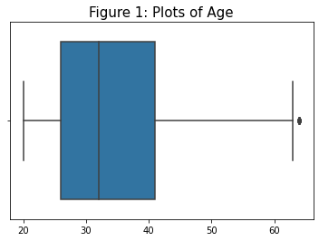

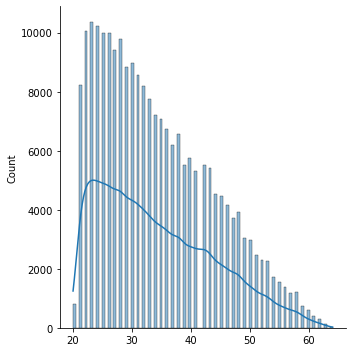

```python
sb.boxplot(data=ldd,x=Age).set_title('Figure 1: Plots of Age', fontsize = 15)
sb.displot(data=ldd,x=Age,kde=True)
```

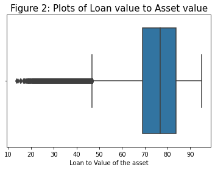

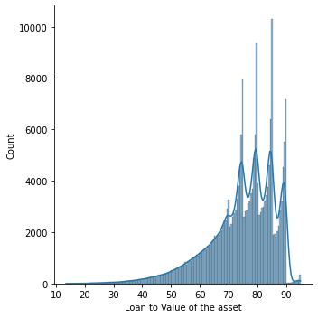

```python
sb.boxplot(data=ldd,x='Loan to Value of the asset').set_title('Figure 2: Plots of Loan value to Asset value', fontsize = 15)
sb.displot(data=ldd,x='Loan to Value of the asset',kde=True)
```

Figure 3: The histogram of `Employment type` exhibit the count of salaried and self employed customers. From Figure 13 It can be observe that the number of self employed customers are as compared to salaried customers

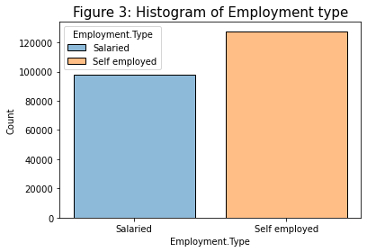

```python
sb.histplot(data=ldd,x='Employment.Type',shrink=0.8,hue='Employment.Type').set_title('Figure 3: Histogram of Employment type',fontsize=15)
```

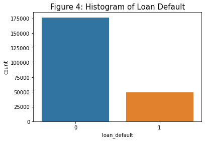

```python
sb.countplot(data=ldd,x='loan_default').set_title('Figure 4: Histogram of Loan Default', fontsize = 15)
```

Figure 5 displays a bar chart of `Bureau score description`. Figure 5 suggest that there were no `Bureau score description` allotted the the maximum number of customers who took the loan while least number of loans were allotted to the category 5 with `very high risk`.

```python
def count_plot(a):
    sb.countplot(data=ldd,x=a)
```

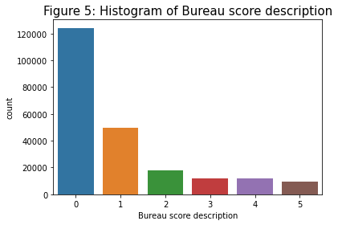

```python
count_plot('Bureau score description')
mpt.title('Figure 5: Histogram of Bureau score description', fontsize=15)
```

Figure 6 displays a histogram of `Age_group`. Figure 6 suggest that most number of loan were allotted to the age group 20-29 while lease number of loans were allotted to the age group 60-70.

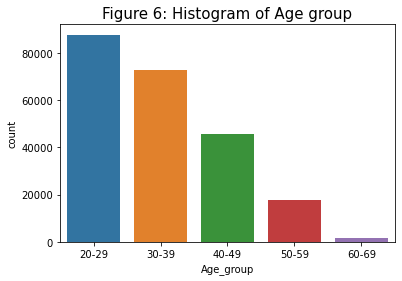

```python
count_plot('Age_group')
mpt.title('Figure 6: Histogram of Age group', fontsize=15)
```

Figure 7 demonstrate that most number of loans were taken against the vehicle with `manufacturer_id`- 86 with 106062 counts followed by IDs '45' and 51 with count 55207 and 26243 respectively, while least number of loans were taken against the vehicle with `manufacturer_id` '153', '152', '156' with count 1, 5 and 11 respectively.

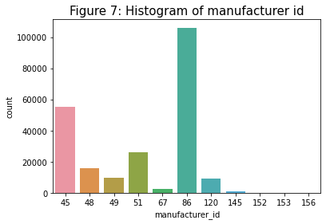

```python
count_plot('manufacturer_id')
mpt.title('Figure 7: Histogram of manufacturer id', fontsize=15)
```

Figure 8 illustrate the count of loan sanctioned by `State_ID`. The most number of loan were sanctioned from the state with state ID `4` while least number of loans were sanctioned from the sate with state_ID `22`

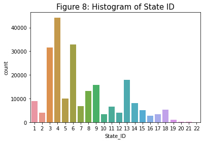

```python
count_plot('State_ID')
mpt.title('Figure 8: Histogram of State ID', fontsize=15)
```

Figure 9 suggests that most number of loans were sanctioned from the `branch_id` - '2' with a count of 13003 while the least number of loan were sanctioned by the branch with `branch_id` - '158'

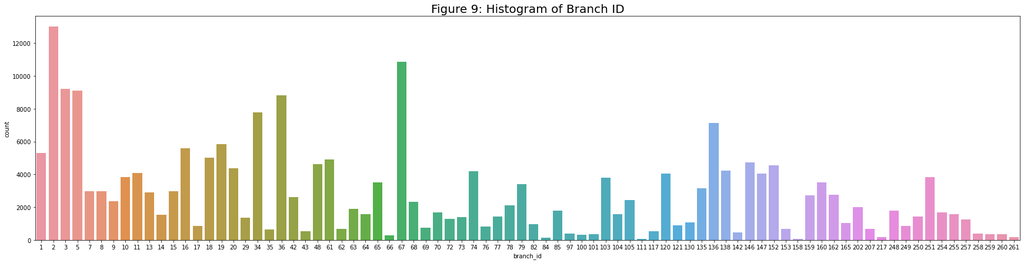

```python
mpt.figure(figsize=(30, 7))
sb.countplot(x="branch_id", data=ldd)
mpt.title('Figure 9: Histogram of Branch ID', fontsize=20)
```

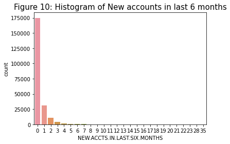

```python
count_plot('NEW.ACCTS.IN.LAST.SIX.MONTHS')
mpt.title('Figure 10: Histogram of New accounts in last 6 months', fontsize=15)
```

From figure 11 more than 80% of the customers doesn't have default account in last 6 months.

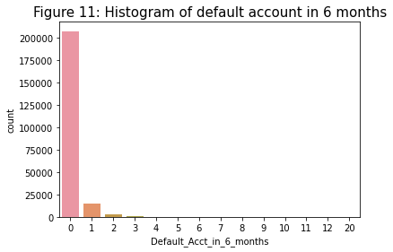

```python
count_plot('Default_Acct_in_6_months')
mpt.title('Figure 11: Histogram of default account in 6 months', fontsize=15)
```

## Multivariate Visualization

Figure 12 Illustrates the number of time a customer made an inquiry for loan classified into the customers Employment type.

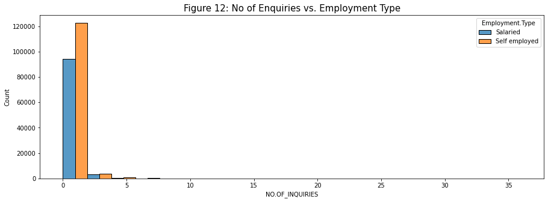

```python
mpt.figure(figsize=(15, 5))
sb.histplot(data=ldd,x='NO.OF_INQUIRIES',hue='Employment.Type',multiple="dodge")
mpt.title('Figure 12: No of Enquiries vs. Employment Type', fontsize=15)
```

Figure 13 illustrates the number of `loan default` categorized into employment type. Compared to Salaried employees, self-employed customer have higher percent of defaulters and non-defaulters.

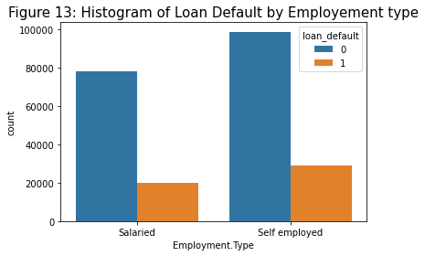

```python
sb.countplot(x='Employment.Type',hue='loan_default',data=ldd).set_title('Figure 13: Histogram of Loan Default by Employement type', fontsize = 15)
```

Figure 14 illustrate the bar chart of number of customers who shared their `mobile number` by `loan default`. It can be observed that all customer have shared their mobile number and more than 75% of people who shared their number have not defaulted the loan.

```python
def countplotmv(a):
    sb.countplot(x=a,hue='loan_default',data=ldd)
```

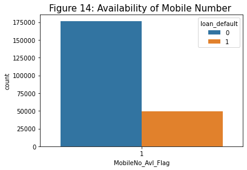

```python
countplotmv('MobileNo_Avl_Flag')
mpt.title('Figure 14: Availability of Mobile Number ', fontsize=15)
```

Figure 15 illustrate the bar chart of number of customers who shared their `Pan number` by `loan default`. Most of the customer haven't shared their Pan number and in that around 20% of customer have defaulted their loan.

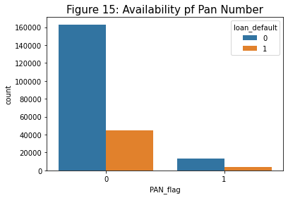

```python
countplotmv('PAN_flag')
mpt.title('Figure 15: Availability pf Pan Number', fontsize=15)
```

Figure 16 illustrate the bar chart of number of customers who shared their `voter id` by `loan default`. Most of the customer haven't shared their voter id. Comparing to previous figure 15 the percent of people who share their voter id is more than pan number.

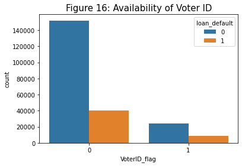

```python
countplotmv('VoterID_flag')
mpt.title('Figure 16: Availability of Voter ID', fontsize=15)
```

Figure 17 illustrate the bar chart of number of customers who shared their `Passport` by `loan default`. The number of customer who have share their passport is negligible while comparing to other ID's.

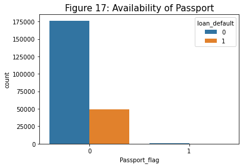

```python
countplotmv('Passport_flag')
mpt.title('Figure 17: Availability of Passport', fontsize=15)
```

Figure 18 illustrate the bar chart of number of customers who shared their `Aadhar Card` by `loan default`. It can be observed that maximum customers shared their Aadhar card when compared to other id's. In that more than 60% customer have not defaulted the loan.

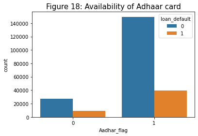

```python
countplotmv('Aadhar_flag')
mpt.title('Figure 18: Availability of Adhaar card', fontsize=15)
```

Figure 19 illustrate the bar chart of number of customers who shared their `Driving license` by `loan default`. Most of the customer have not shred their driving license.

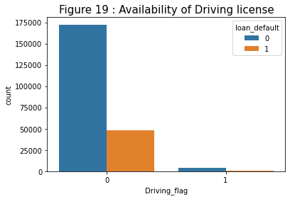

```python
countplotmv('Driving_flag')
mpt.title('Figure 19 : Availability of Driving license', fontsize=15)
```

Figure 20 illustrates a lineplot of Primary EMI by Age. The graphs suggest that there is a positive relationship between Age and the amount of Primary EMI. The EMI amount shoots up for customers who are above 60 years old.

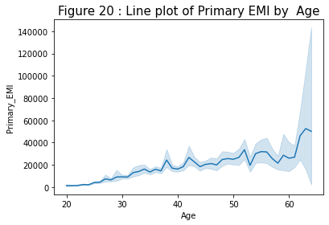

```python
sb.lineplot(data=ldd,x='Age',y='Primary_EMI').set_title('Figure 20 : Line plot of Primary EMI by  Age', fontsize = 15)
```

Figure 21 shows a bar plot of loan default status of customers at first EMI broken down by Employment type and disbursed amount

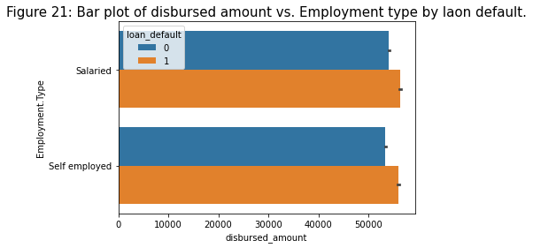

```python
sb.barplot(data=ldd,x='disbursed_amount',y='Employment.Type',hue='loan_default',dodge=True).set_title('Figure 21: Bar plot of disbursed amount vs. Employment type by laon default.', fontsize = 15)
```

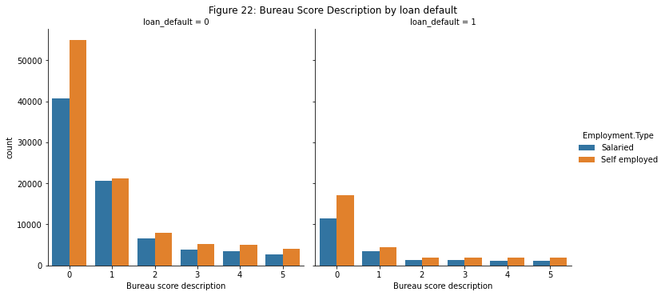

```python
a=sb.catplot(data=ldd,x='Bureau score description',hue='Employment.Type',col='loan_default',kind="count")
a.fig.subplots_adjust(top=0.9)
a.fig.suptitle('Figure 22: Bureau Score Description by loan default')
```

Figure 23 illustrate a line plot of loan default by Bureau Score and Age. It can be seen that there is positive relationship between Bureau Score, Age and loan default or no default.

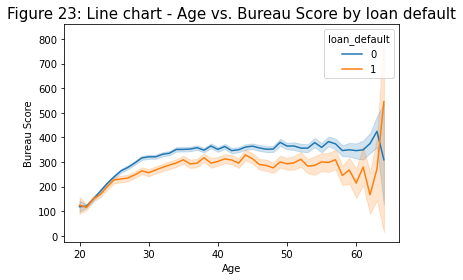

```python
sb.lineplot(data=ldd,x="Age",y='Bureau Score',hue='loan_default')
mpt.title('Figure 23: Line chart - Age vs. Bureau Score by loan default', fontsize=15)
```

From figure 24 we can observe that the density of disbursed amount is more for non defaulters.

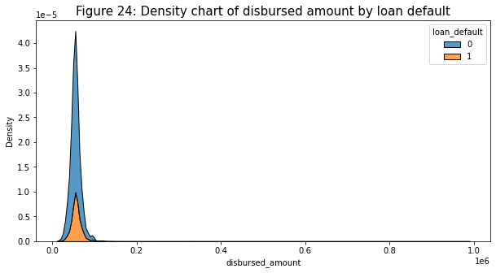

```python
mpt.figure(figsize=(10, 5))
sb.kdeplot(data=ldd,x='disbursed_amount',hue='loan_default',multiple="stack")
mpt.title('Figure 24: Density chart of disbursed amount by loan default', fontsize=15)
```

The figure 25 displays the bar chart of the count of loan default by Employment type and Age group. As we can observe the most number of non-default are made by the age group ranging from 20-29 both in case of salaried and self employed customers. As the age of the customers increase the trend decreases.

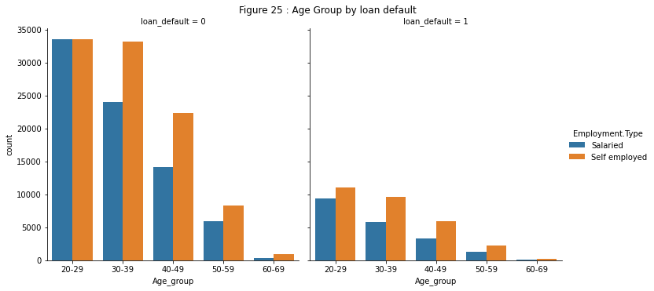

```python
b=sb.catplot(x="Age_group", hue="Employment.Type", col="loan_default",data=ldd, kind="count")
b.fig.subplots_adjust(top=0.9)
b.fig.suptitle('Figure 25 : Age Group by loan default')
```

The bar chart in Figure 26 describes the Bureau Score vs. Age group of the customers by Employment type. The Figure suggests that the Bureau score reaches maximum at the age group of 50-59 in case of salaried customers and in case of Self employed customers the Bureau score reached at the maximum at the age group 60-69. ALthough the minimum bureau score for both Salaried and Self employed customers are at the minimum at the age group 20-29.

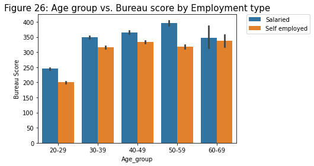

```python
sb.barplot (x="Age_group", y="Bureau Score",hue="Employment.Type",data=ldd)
mpt.legend(bbox_to_anchor=(1.05, 1), loc=2, borderaxespad=0.)
mpt.title('Figure 26: Age group vs. Bureau score by Employment type', fontsize=15)
```

The figure 27 illustrates bar chart of age group vs. average disbursed amount by loan default. It can be interpreted from the graph that the disbursed amount to the loan defaulter and no defaulter of the first EMI diminishes slightly as the age of the customer increase.

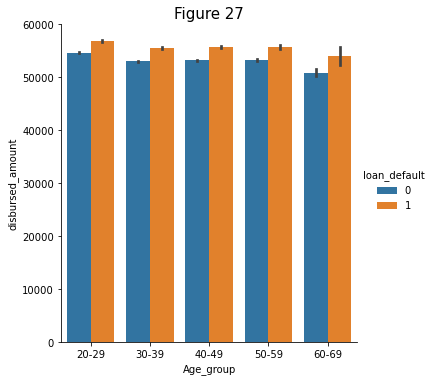

```python
sb.catplot(data=ldd, x='Age_group' , y='disbursed_amount', hue= 'loan_default',  kind="bar")
mpt.title('Figure 27', fontsize=15)
```

# Summary and Conclusion

In Phase 1 of the project we carried out Data Preprocessing and Visualization. The dataset was made ready for further modeling and prediction in Phase 2. The unnecessary attributes where removed from the dataset and necessary preprocessing and transformation was done on the required attributes such has handling missing values, doing required data type conversion of attributes, creating new variables such as Age, Age_range, Average_Tenure and CREDIT.HISTORY.LENGTH for better understanding and visualization, encoding of category variable to numerical values. The features and the relationship between features were explored through visualization.  
A few observations :

- loan default clients were on 22% of the dataset.
- Self Employed category holds more than 50% of the loan
- Age and Bureau Score are in positive relation
- Most number of loans were taken among the younger age group between 19 to 30.
- Most of the customer only provide Adhaar card details while taking loan.

A more detailed data analysis would be carried out in Phase 2 were the modeling and prediction will be done with the dataset.

# Reference

1. LoanDefault_LTFS_AV(ML_FINHACK). (2021). Retrieved 10 April 2021, from https://www.kaggle.com/lampubhutia/loandefault-ltfs-avml-finhack
2. seaborn: statistical data visualization — seaborn 0.11.1 documentation. (2021). Retrieved 10 April 2021, from https://seaborn.pydata.org/index.html
3. Gallery — Matplotlib 3.4.1 documentation. (2021). Retrieved 10 April 2021, from https://matplotlib.org/stable/gallery/index.html
4. User Guide — pandas 1.2.3 documentation. (2021). Retrieved 10 April 2021, from https://pandas.pydata.org/pandas-docs/stable/user_guide/index.html
5. Regression Case Study | www.featureranking.com. (2021). Retrieved 10 April 2021, from https://www.featureranking.com/tutorials/statistics-tutorials/regression-case-study/